# AIM assessments comparison between sites in Lothian

Marcus J Lyall

June 9, 2018

## Background

This Quality improvement project is designed to analyse patients attending WGH and RIE acute medical units with a view to - Understanding temporal patterns in attendance - Mapping staffing to attendance times.

## Methods

Data were obtained from the TRAK care system Intersystems, US) in use in all hospital sites in Lothian. Data were processed in R version 3.4.1 https://www.r-project.org. A detailed description of data processing script can be seen in the R Markdown document by clicking the grey ‘code’ tab.

## Results.

```
##   WGH   RIE
## 20040  9604
```

quartery attendace numbers were as below.

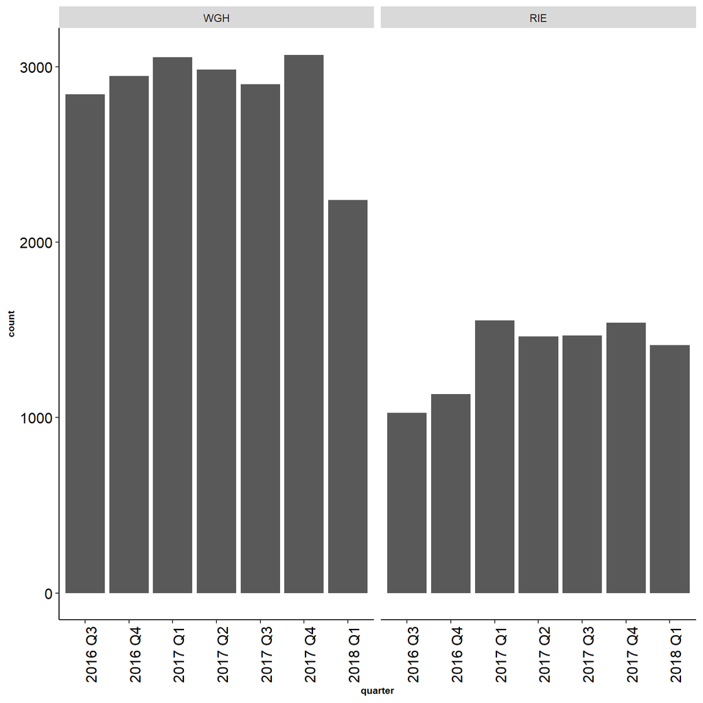

## Diurnal variation in arrival

Mean number of attendances was calculated for each our over each quarter for the past year to examine attendance profiles. error bars = min and max attendances. Weekdays only included.

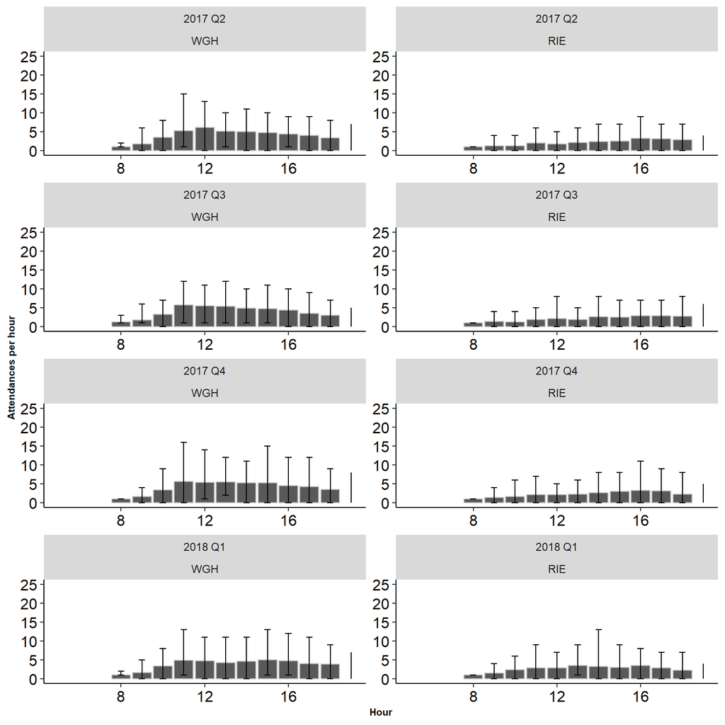

## How are admissions changing over time

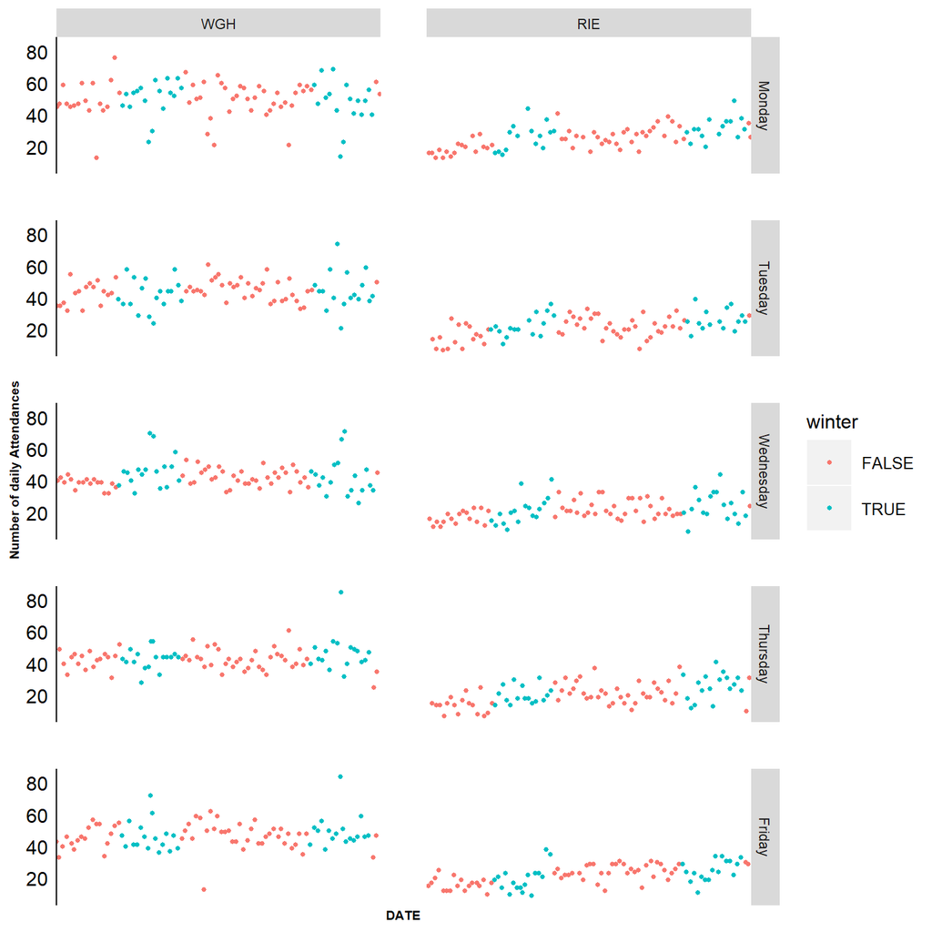

## with linear modelling line to determine trend.

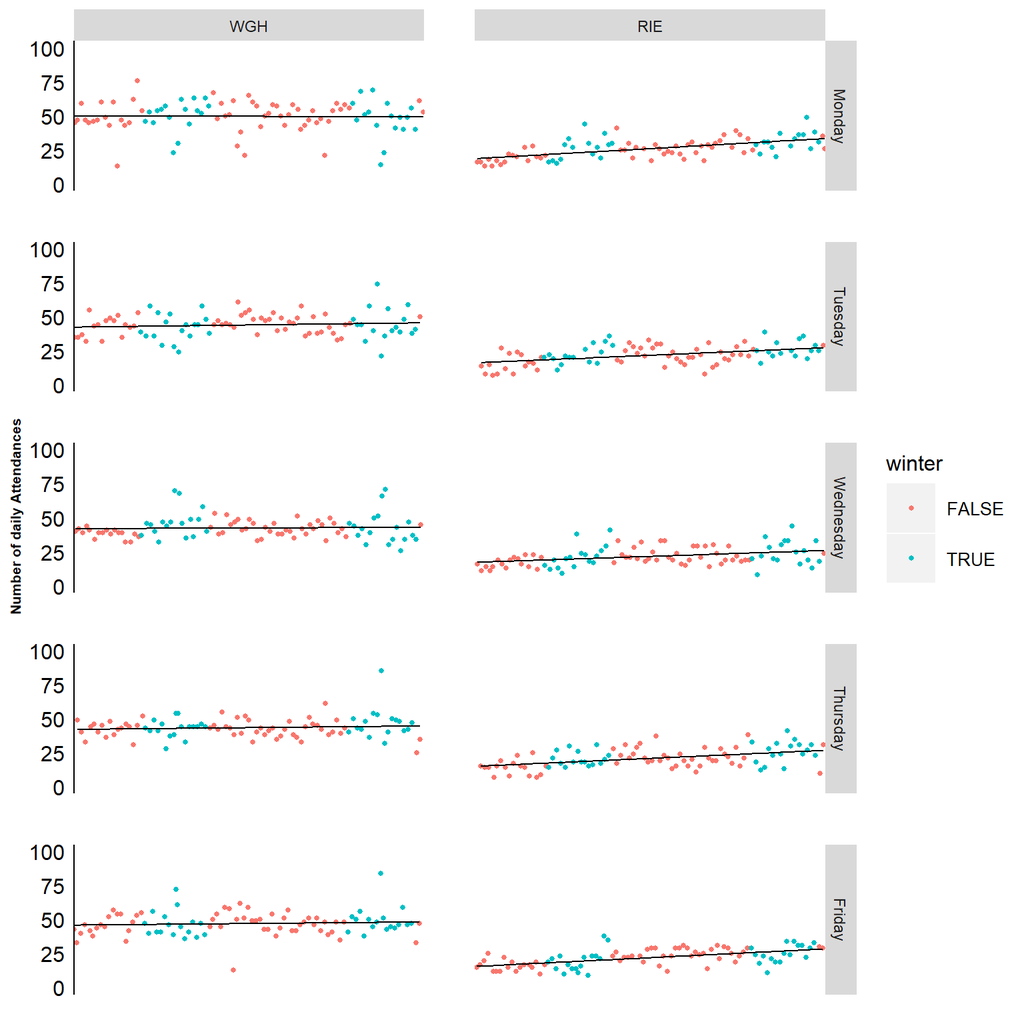

It looks like WGH is not increasing at all but RIE attendance is increasing sharply. The statistics for this trend are then calculated below. THe P-value in the last column tells us whether there is a significant change over time. The ‘estimate’ column tells us the direction of the change and the size of the change (in number of patients per week). I’ve then added a column to the RIE section showing how may weeks there are to each extra attendance based on the liner model.

| WGH_model | term | estimate | std.error | statistic | p.value |
| --- | --- | --- | --- | --- | --- |
| Monday | obs | -0.0086313 | 0.0482774 | -0.1787845 | 0.8585226 |
| Tuesday | obs | 0.0036505 | 0.0036723 | 0.9940642 | 0.3229804 |
| Wednesday | obs | 0.0011667 | 0.0035172 | 0.3317158 | 0.7409109 |
| Thursday | obs | 0.0029090 | 0.0033522 | 0.8678014 | 0.3879182 |
| Friday | obs | 0.0026581 | 0.0037558 | 0.7077390 | 0.4809990 |

| RIE_model | term | estimate | std.error | statistic | p.value | weeks_to_extra_attendance |
| --- | --- | --- | --- | --- | --- | --- |
| Monday | obs | 0.1860434 | 0.0294007 | 6.327864 | 0.0000000 | 5.375091 |
| Tuesday | obs | 0.0126850 | 0.0028463 | 4.456706 | 0.0000265 | 78.833364 |
| Wednesday | obs | 0.0099775 | 0.0028988 | 3.441975 | 0.0008938 | 100.225420 |
| Thursday | obs | 0.0135354 | 0.0029179 | 4.638763 | 0.0000126 | 73.880404 |
| Friday | obs | 0.0148351 | 0.0023579 | 6.291565 | 0.0000000 | 67.407699 |

As expected WGH attendance has not increased at all over the analysis period. RIE continues to increase on each weekday with a highly significant p-value. The Monday effect continues with an average of 1 extra patient per 5 weeks.

## What are the discharge rates for each site

I then looked at the discharge rates for each site to see whether there was a significant difference.

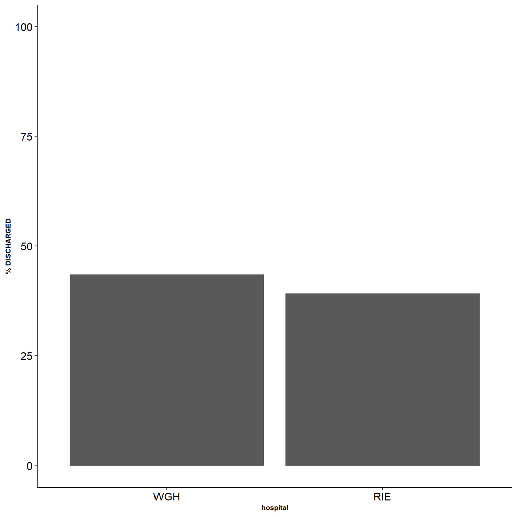

```
## # A tibble: 2 x 5
## # Groups:   hospital [2]
##   hospital admitted     n  prop PercentageDC
##   <fct>    <fct>    <int> <dbl>        <dbl>
## 1 WGH      FALSE     8727 0.435         43.5
## 2 RIE      FALSE     3766 0.392         39.2
```

RIE immediatedly discharges 39.2% of attendances where as WGH discharges 43.54 percent. A chi sq test can be used to see if this is a significant difference (below) and unsurprisingly given the size of the dataset this is highly significant.

```
##
##       FALSE  TRUE
##   WGH  8727 11313
##   RIE  3766  5838
```

```
##   statistic      p.value parameter
## 1  49.86313 1.648533e-12         1
##                                                         method
## 1 Pearson's Chi-squared test with Yates' continuity correction
```

## Discharge percentage depending on time of arrival.

We noted at RIE that there was a distinct pattern of the likelihood of discharge based on the time that the patient arrived. I performed the same analysis at WGH to see if the effect was replicated

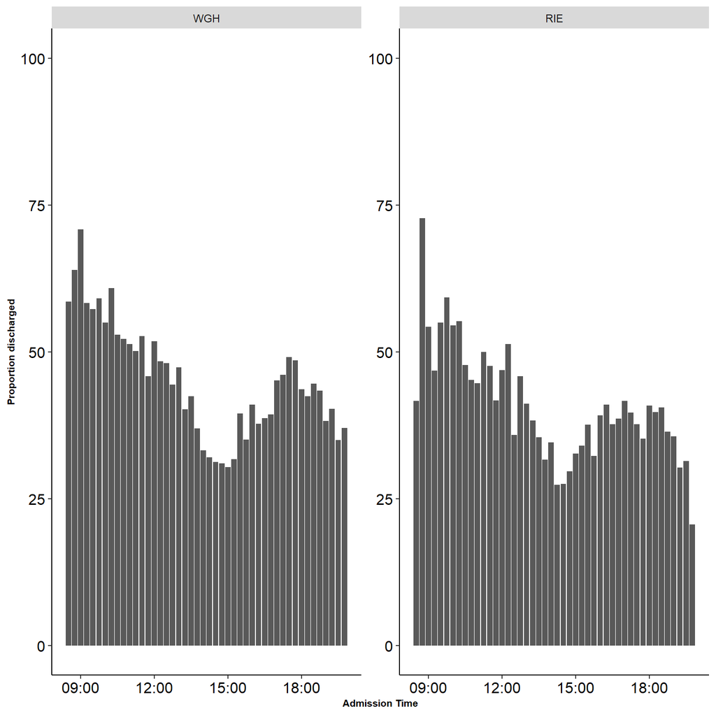

It appears that the pattern is almost identical!! It will be interesting to ask the primary care team why this is but I have my own ideas. THis is useful however as we now surely know that 2-3pm will have a high demand for beds being requested in AMAUB and AMURIE due to higher attendance and higher proportions admittted.

- I’m still looking at time to cubical at at WGH and RIE and mapping staff hours to attendance demand - a bit slowed down by job applications.